# Lecture 5 — Distribution Charts (Histogram, Box Plot & Violin Plot

> **Dataset:** Airbnb London Listings (https://insideairbnb.com/get-the-data/)

> **Source of figures:** Knaflic, C. N. (2015). *Storytelling with data*. Wiley.

## Opening: Model Answer Review

## Design Principles - Part I: Text is Your Friend

*Ticket chart with titles and axis labels added — text makes it accessible [ FIGURE 5.9 — p.144 ]*

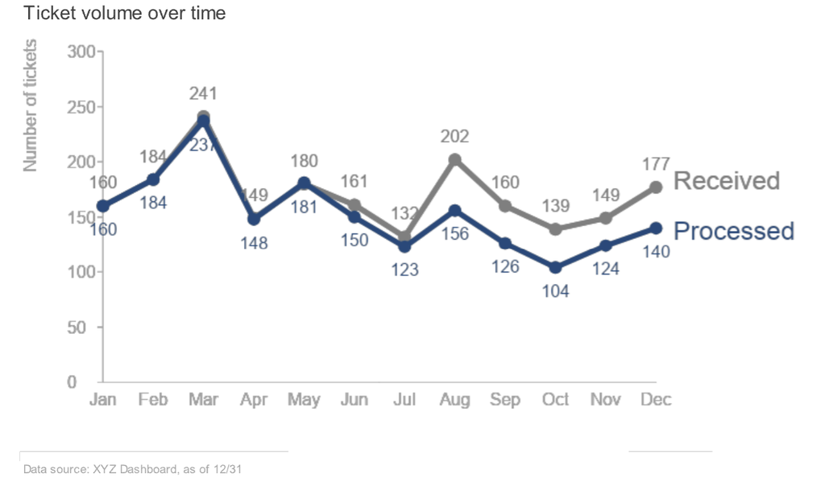

**[ FIGURE 5.10 — p.144 ]**

*Same chart with action title and annotation — the call to action is now clear [ FIGURE 5.10 — p.144 ]*

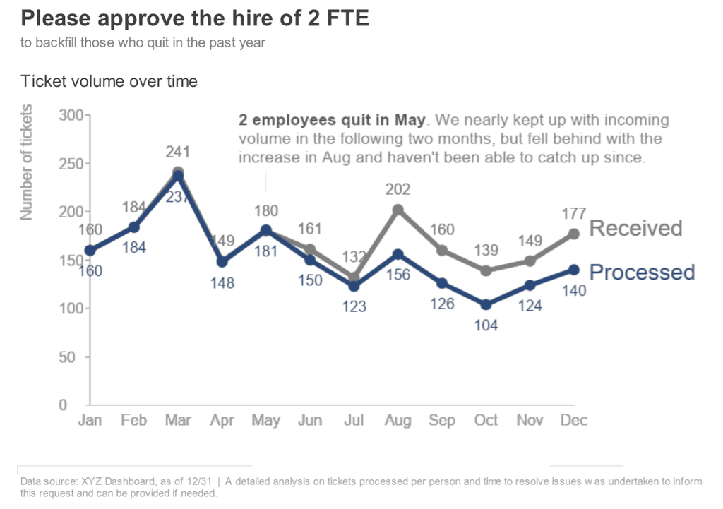

## Design Principles - Part II: Why Distributions?

### The mean hides everything

The mean collapses the entire shape of the data into one number — and for skewed data like prices, it is almost always misleading**

> 💡 **median, range, IQR, what % are below £100, etc. offer a more accurate representation of the data**

**Three charts for understanding distributions:**

| Chart | Best for | When to use |
| --- | --- | --- |
| Histogram | Shape of ONE distribution | Where are the values concentrated? |
| Box plot | Comparing MANY groups compactly | Quick comparison of medians + spread |
| Violin plot | Comparing groups WITH shape | When shape matters (bimodal, skewed) |

> 💡**Distribution charts are often the hardest to title well because the shape IS the story. You need words to interpret the shape for your audience. Don't make them figure out what the skew means — tell them**

**Text rules for distribution charts:**

- Always name the distribution shape in the title ('right-skewed', 'concentrated around', 'bimodal')
- Add a vertical line for mean and/or median — annotate which is which
- Explain outliers: are they errors or interesting? Annotate them